# sept 8 rna seq

```r
setwd("~/Desktop/Lab/TRAP_Stats_08302023/Scripts")
```

```r
library(readr)
featcount <- read_table("featcount.txt",
                        col_names = TRUE, skip = 1)
read.count <- data.frame(featcount,row.names = featcount$Geneid ) #gene ids stored as row names
geneID<- featcount$Geneid

read.count <- read.count [ ,-c(1:6)] #removes the columns without gene counts not the same as bottom row code

orig_names <- names (read.count)
#print(orig_names)
```

```r
colnames(read.count) <- (c("IT-107","IT-108", "IT-109", "IT-110", "H-107", "H-108", "H-109", "H-110","H-111", "UT-106", "UT-108", "UT-114", "IT-206", "IT-207", "IT-208", "IT-209", "IM-206", "IM-207", "IM-208", "IM-209", "IM-210", "UT-204", "UT-208", "UT-213", "UT-214", "UM-204", "UM-208", "UM-213", "UM-214", "UM-215"))
#view(read.count)

ImvH <- read.count [ ,-c(1:4, 10:16,22:30)]

sample_info <- data.frame(
   sample = c( "H-107", "H-108", "H-109", "H-110","H-111","IM-206", "IM-207", "IM-208", "IM-209", "IM-210"),
   groups=c( "H", "H", "H", "H","H",  "IM", "IM", "IM", "IM", "IM"),
   replicate= c("H-107", "H-108", "H-109", "H-110","H-111", "IM-206", "IM-207", "IM-208", "IM-209", "IM-210"),
    row.names = "sample")

sample_info$groups<- as.factor(sample_info$groups)
all(rownames(sample_info) %in% colnames(ImvH)) #if false something is wrong
```

```
[1] TRUE
```

```r
sample_info
```

|  | groups | replicate |
| --- | --- | --- |
| H-107 | H | H-107 |
| H-108 | H | H-108 |
| H-109 | H | H-109 |
| H-110 | H | H-110 |
| H-111 | H | H-111 |
| IM-206 | IM | IM-206 |
| IM-207 | IM | IM-207 |
| IM-208 | IM | IM-208 |
| IM-209 | IM | IM-209 |
| IM-210 | IM | IM-210 |

```r
colnames(read.count) <- (c("IT-107","IT-108", "IT-109", "IT-110", "H-107", "H-108", "H-109", "H-110","H-111", "UT-106", "UT-108", "UT-114", "IT-206", "IT-207", "IT-208", "IT-209", "IM-206", "IM-207", "IM-208", "IM-209", "IM-210", "UT-204", "UT-208", "UT-213", "UT-214", "UM-204", "UM-208", "UM-213", "UM-214", "UM-215"))
#view(read.count)

sample_info <- data.frame(
   sample = c("IT-107","IT-108", "IT-109", "IT-110", "H-107", "H-108", "H-109", "H-110","H-111", "UT-106", "UT-108", "UT-114", "IT-206", "IT-207", "IT-208", "IT-209", "IM-206", "IM-207", "IM-208", "IM-209", "IM-210", "UT-204", "UT-208", "UT-213", "UT-214", "UM-204", "UM-208", "UM-213", "UM-214", "UM-215"),
   condition = c("infected", "infected", "infected", "infected", "infected", "infected", "infected","infected","infected","mock","mock","mock","infected","infected","infected","infected","infected","infected","infected","infected","infected","mock","mock","mock","mock","mock","mock","mock","mock","mock"),
   groups=c("IT","IT","IT", "IT", "H", "H", "H", "H","H", "UT", "UT", "UT", "IT", "IT", "IT", "IT", "IM", "IM", "IM", "IM", "IM", "UT", "UT", "UT", "UT", "UM", "UM", "UM", "UM", "UM"),
   replicate= c("IT-107","IT-108", "IT-109", "IT-110", "H-107", "H-108", "H-109", "H-110","H-111", "UT-106", "UT-108", "UT-114", "IT-206", "IT-207", "IT-208", "IT-209", "IM-206", "IM-207", "IM-208", "IM-209", "IM-210", "UT-204", "UT-208", "UT-213", "UT-214", "UM-204", "UM-208", "UM-213", "UM-214", "UM-215"),
   rna_type_collected= c( "all","all","all","all","translated","translated","translated","translated","translated","all","all","all","all","all","all","all","translated","translated","translated","translated","translated","all","all","all","all","translated","translated","translated","translated","translated"),
   rna_vs_trap= c("rna","rna","rna","rna","trap","trap","trap","trap","trap","rna","rna","rna","rna","rna","rna","rna","trap","trap","trap","trap","trap","rna","rna","rna","rna","trap","trap","trap","trap","trap"),
    row.names = "sample")

sample_info$groups<- as.factor(sample_info$groups)
sample_info$condition<- as.factor(sample_info$condition)
all(rownames(sample_info) %in% colnames(read.count)) #if false something is wrong
```

```
[1] TRUE
```

```r
sample_info
```

|  | condition | groups | replicate | rna_type_collected | rna_vs_trap |
| --- | --- | --- | --- | --- | --- |
| IT-107 | infected | IT | IT-107 | all | rna |
| IT-108 | infected | IT | IT-108 | all | rna |
| IT-109 | infected | IT | IT-109 | all | rna |
| IT-110 | infected | IT | IT-110 | all | rna |
| H-107 | infected | H | H-107 | translated | trap |
| H-108 | infected | H | H-108 | translated | trap |
| H-109 | infected | H | H-109 | translated | trap |
| H-110 | infected | H | H-110 | translated | trap |
| H-111 | infected | H | H-111 | translated | trap |
| UT-106 | mock | UT | UT-106 | all | rna |

[output cut: 20 more lines]

```r
#sum(read.count)
```

```r
library(DESeq2)

dds <- DESeqDataSetFromMatrix(countData = ImvH,
                              colData = sample_info,
                              design = ~groups)
print(dds)
```

```
class: DESeqDataSet
dim: 38295 10
metadata(1): version
assays(1): counts
rownames(38295): AT1G01010 AT1G01020 ... ArthCp084 ArthCp085
rowData names(0):
colnames(10): H-107 H-108 ... IM-209 IM-210
colData names(2): groups replicate
```

```r
library(magrittr)
library(vsn)
#prefiltering


dds <- (dds[ rowSums( counts(dds) ) > 10 , ])
dds$groups<-relevel(dds$groups, ref = "IM")


summary(dds$groups)
```

```
IM  H
 5  5
```

```r
#if (!require("BiocManager", quietly = TRUE))
#    install.packages("BiocManager")

#BiocManager::install("apeglm")

library(AnnotationDbi)
library(apeglm)
dds <- DESeq(dds)
res <- results(dds,
               independentFiltering = TRUE)


summary(res)
```

```
out of 21555 with nonzero total read count
adjusted p-value < 0.1
LFC > 0 (up)       : 4749, 22%
LFC < 0 (down)     : 4765, 22%
outliers [1]       : 7, 0.032%
low counts [2]     : 0, 0%
(mean count < 1)
[1] see 'cooksCutoff' argument of ?results
[2] see 'independentFiltering' argument of ?results
```

```r
print(res)
```

[output not shown]

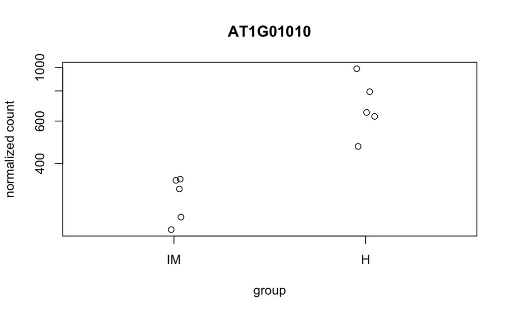

```r
#Plot the counts of some of the top differentially expressed genes as a sanity check:
plotCounts(dds,gene="AT1G01010",intgroup="groups")
```

```r
dev.copy2pdf(file="all_plotCounts.pdf")
```

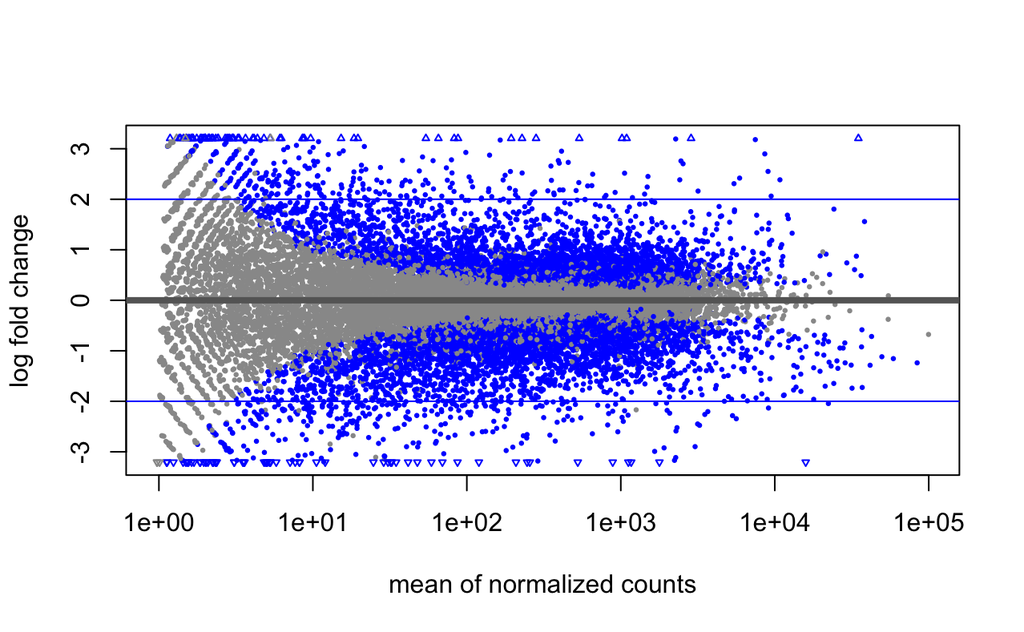

```r
#Plot the log2 Fold Changes as function of expresson:
plotMA(res,alpha=0.05)
abline(h=c(-2,2),col="blue")
```

#baseMean, is a just the average of the normalized count values, dividing by sizefactors, taken over all samples.

#log2FoldChange is the effect size estimate. It tells us how much the gene’s expression seems to have changed due to treatment in comparison to control. This value is reported on a logarithmic scale to base 2: for example, a log2 fold change of 1.5 means that the gene’s expression is increased by a multiplicative factor of 2^1.5~2.82

#L2FC estimate has an uncertainty associated with it, which is available in the column lfcSE,the standard error estimate for the log2 fold change estimate.

#We can also express the uncertainty of a particular effect size estimate as the result of a statistical test. The purpose of a test for differential expression is to test whether the data provides sufficient evidence to conclude that this value is really different from zero. DESeq2 performs for each gene a hypothesis test to see whether evidence is suffcient to decide against the null hypothesis that there is no effect of the treatment on the gene and that the observed difference between treatment and control was merely caused by experimental variability (i. e., the type of variability that you can just as well expect between di erent samples in the same treatment group). As usual in statistics, the result of this test is reported as a p value, and it is found in the column pvalue. (Remember that a p value indicates the probability that a fold change as strong as the observed one, or even stronger, would be seen under the situation described by the null hypothesis.)

#We note that a subset of the p values in res are NA (available”). This is DESeq’s way of reporting that all counts for this gene were zero, and hence not test was applied. In addition, p values can be assigned NA if the gene was excluded from analysis because it contained an extreme count outlier.

#DESeq2 uses the so-called Benjamini-Hochberg (BH) adjustment; in brief, this method calculates for each gene an adjusted p value which answers the following question: if one called signi cant all genes with a p value less than or equal to this gene’s p value threshold, what would be the fraction of false positives (the false discovery rate, FDR) among them (in the sense of the calculation outlined above)? These values, called the BH-adjusted p values, are given in the column padj of the results object.

```r
library(vsn)
resultsNames(dds) # lists the coefficients
```

```
[1] "Intercept"      "groups_H_vs_IM"
```

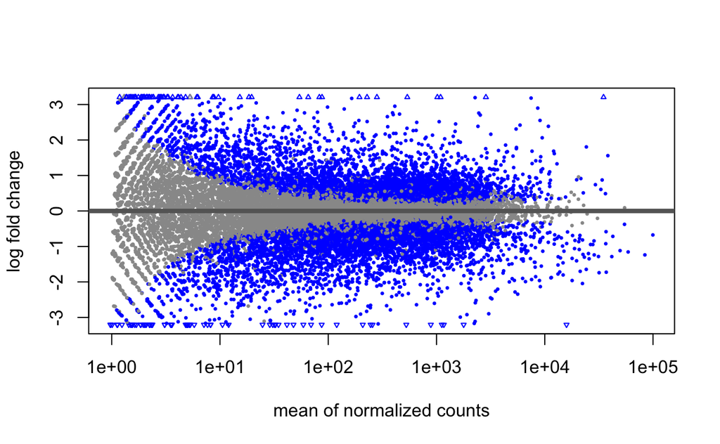

```r
#plotMA(dds)
vsd <- vst(dds, blind = TRUE )

plotMA(res)
```

```r
NA
NA
```

```r
library(ggplot2)

head(assay(dds))
```

[output not shown]

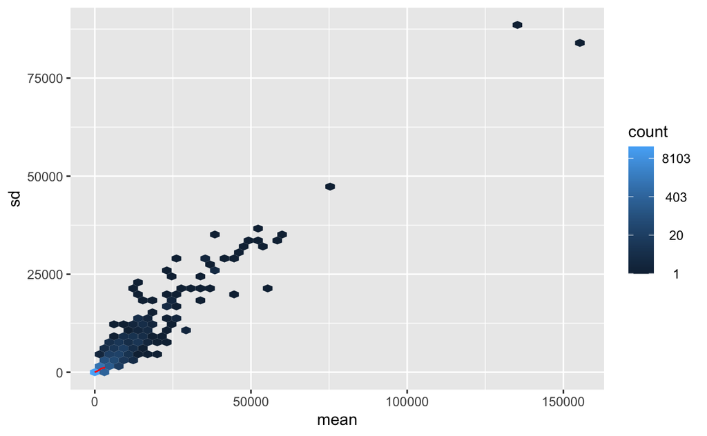

```r
par(mfrow=c(1,2))
meanSdPlot(assay(dds), ranks=FALSE)
```

```r
head(assay(vsd), 3)
```

[output not shown]

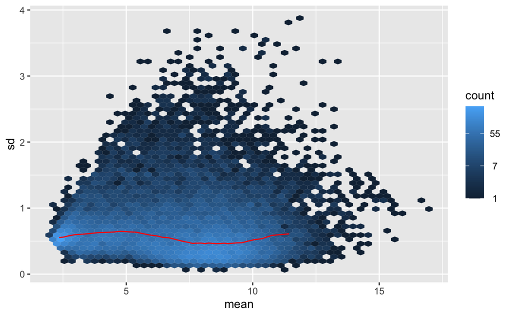

```r
#assay(rld)#[ 1:3, 1:3]
meanSdPlot(assay(vsd), ranks=FALSE)
```

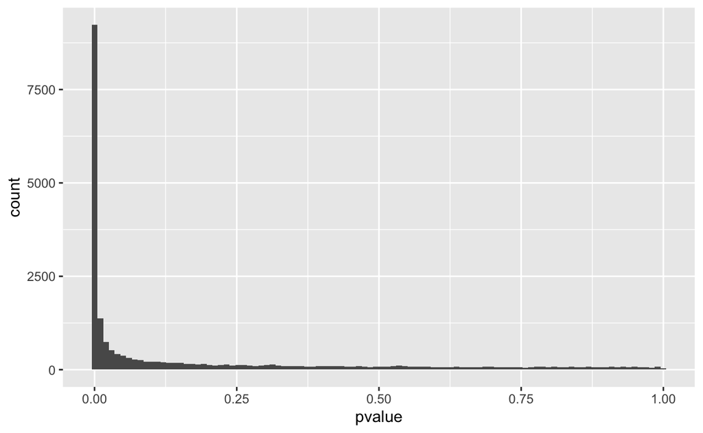

```r
#P-value distribution genes before adjusting for multiple testing.
ggplot(data =as.data.frame(res),aes(x =pvalue))+geom_histogram(bins =100)
```

```r
NA
NA
```

```r
# PCA
library(ggfortify)
library(ggrepel)
library (ggplot2)
library(pheatmap)
library(devtools)
#summary(res)
#print(res)

pcadata<- plotPCA(vsd,
        intgroup=c("replicate","groups"), returnData = TRUE)
summary(pcadata)
```

[output not shown]

[figure not shown]

```r
percentVar <- round(100 * attr(pcadata, "percentVar"))



#  geom_hline(yintercept = 0, lty = 2) +
#  geom_vline(xintercept = 0, lty = 2) +

p <- ggplot(pcadata, aes(PC1,PC2, label = replicate, colour = groups )) +
  geom_point(size=3)

p2 <- p + geom_text_repel(box.padding = 0.5, max.overlaps = 15, segment.linetype = 2) + labs(title = "vst transformed counts") +
  xlab(paste0("PC1: ",percentVar[1],"% variance")) +
  ylab(paste0("PC2: ",percentVar[2],"% variance"))
p2
```

```r
dev.copy2pdf(file="PCA")
```

```r
library("gplots")
library("RColorBrewer")

#making distance matrix
Dists <- dist(t( assay(vsd) ) )
Dists
```

```
           H-107     H-108     H-109     H-110     H-111    IM-206    IM-207    IM-208    IM-209
H-108   56.37453
H-109   80.84428  66.91903
H-110   49.13727  73.21398  79.05857
H-111   68.19457  81.61344  71.69737  51.07229
IM-206  95.65931 100.90650 113.71335 102.22355 116.70158
IM-207  93.88474 111.60067 118.94607  87.19595  97.21363  75.98198
IM-208  87.78490  91.08300  99.02280  87.33608  99.04000  63.44803  60.93532
IM-209 110.96780 108.19129 100.44434 105.50142 106.81400  75.63248  78.38310  56.19105
IM-210 109.16571 122.07818 126.64038  98.08045 103.82979  85.88810  51.04067  68.54008  77.24174
```

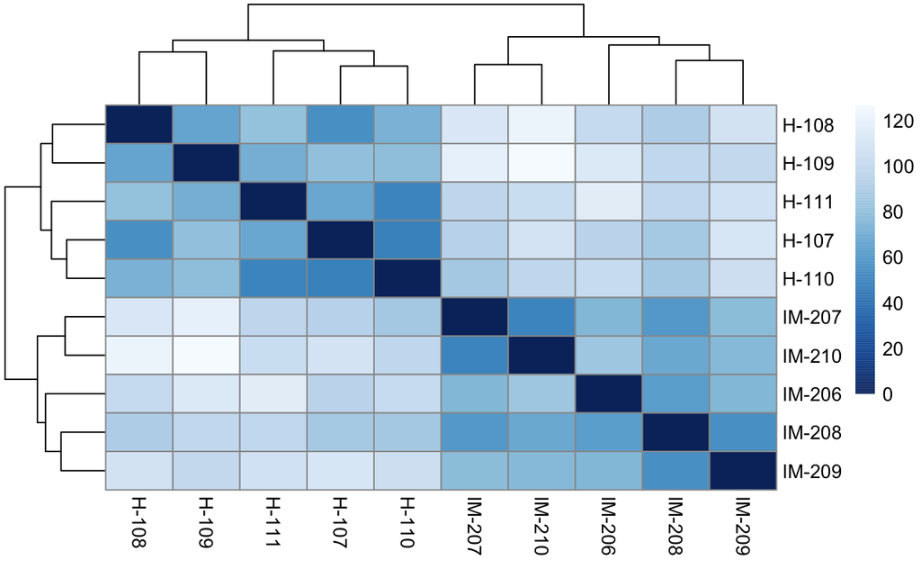

```r
DistMatrix <- as.matrix( Dists )
rownames(DistMatrix) <- paste(vsd$replicate,  sep="-" )
colnames(DistMatrix)<-paste(vsd$replicate,  sep="-" )


#color scheme
colors <- colorRampPalette( rev(brewer.pal(9, "Blues")) )(255)

#generate heat map
pheatmap(DistMatrix,
 clustering_distance_rows=Dists,
 clustering_distance_cols=Dists,
 col=colors)
```

```r
#summary(DistMatrix)
#boxplot(DistMatrix,
#        main = "Dist to Dist summary",
#        xlab = "Replicate",
#        col = rld$groupS,
#        border = "brown")
```

[figure not shown]

```r
# Construct a dendogram for samples
#install.packages("ggdendro")
library(ggdendro)
library(magrittr)
library(dendextend)

clusterTree <- hclust(dist(t( assay(vsd))), method="average")
sampleTree <- as.dendrogram(clusterTree)

sampleTree <- sampleTree %>%
  color_branches(k = 2)

 plot(sampleTree)
```

[figure not shown]

```r
#attributes

#get_nodes_attr(sampleTree, "midpoint")
#get_nodes_attr(sampleTree, "height")
#assign_values_to_leaves_nodePar(sampleTree)
#heights_per_k.dendrogram(sampleTree)


topVarGenes<-head(order(rowVars(assay(vsd)),decreasing=TRUE),25)
pheatmap(assay(vsd)[topVarGenes,],scale="row",col=colorRampPalette(rev(brewer.pal(9,"RdBu")))(255))
```

```r
library(dplyr)
library(pheatmap)

res05 <- results(dds,
               independentFiltering = TRUE,
               alpha = 0.1,
               lfcThreshold = .5)
summary(res05)
```

```
out of 21555 with nonzero total read count
adjusted p-value < 0.1
LFC > 0.50 (up)    : 833, 3.9%
LFC < -0.50 (down) : 1161, 5.4%
outliers [1]       : 7, 0.032%
low counts [2]     : 0, 0%
(mean count < 1)
[1] see 'cooksCutoff' argument of ?results
[2] see 'independentFiltering' argument of ?results
```